# Learning Stan

This code follows the tutorial posted at [Weird Fishes](https://www.weirdfishes.blog/blog/fitting-bayesian-models-with-stan-and-r)

```r
/*
You can do long blocks of comments like this.
*/

data{
// load data
}

parameters{
// define parameters the model is trying to estimate
}

model{
// the posterior probability function
}
```

Suppose we have N observations of Y data, where N is an integer and Y is a vector of real numbers. We would declare those like:

```r
data{

int N; // the number of observations
vector[N] Y; // our data

}
```

This tells Stan that we have an integer object N, and we have a vector Y of length N.

We can also declare arrays:

```r
data{

int N; // the number of observations
vector[N] Y; // our data
real X[N];

}
```

A few examples of this:

```r
real x[10];
real y[10];
real z[10];

z = x * y


vector[10] x;
vector[10] y;
vector[5] z;

z = x[1:5] .* y[1:5];
```

You can also set bounds on almost anything:

```stan
data{

int n; // the number of observations

vector[n] y; //

vector<lower = 0>[n] x; // constrains x to be positive [0, Inf]

}
```

Could also set an upper limit: `<lower = 0, upper = 100>`.

The bounds are useful in the parameters block when we are estimating certian values like standard deviation that must be positive. Rather than extimating $\log(\sigma)$ we could just set the bounds:

```stan
parameters{

  real<lower = 0> sigma;

}
```

This tells Stan to only look for positive values and even lets us use normal priors:

```stan
model{

  sigma ~ normal(0, 2);

}
```

This equlivelant to saying that our prior on sigma is half normal, with standard deviation 2.

# Example Model: Predicting Salmon

We will predict the number of young fish produced by a given amount of adult fish.

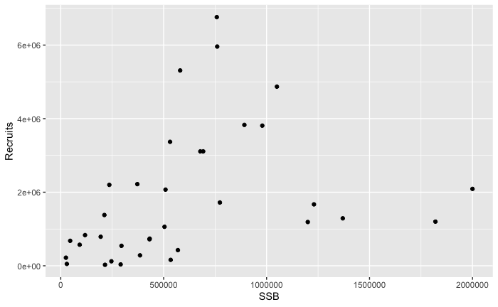

```r
library(tidyverse)
sr_data <- read_csv("/Users/nick/Documents/Workshops & Conferences/Statistical Rethinking/rlsadb_v4.25_ssb_recruits.csv") %>%
  set_names(tolower)
sal_data <- sr_data %>%
  filter(stockid == 'PSALMAKPSWUD') %>%
  select(stocklong, year, ssb, r) %>%
  na.omit()

sal_data %>%
  ggplot(aes(ssb, r)) +
  geom_point() +
  labs(x = "SSB", y = "Recruits")
```

```r
glimpse(sal_data)
```

```
Observations: 35
Variables: 4
$ stocklong <chr> "Pink Salmon AK Pen Southwest and Unimak Districts", "Pink Salmon AK Pen Southwest and Unimak Districts", "Pink Sa…
$ year      <dbl> 1962, 1963, 1964, 1965, 1966, 1967, 1968, 1969, 1970, 1971, 1972, 1973, 1974, 1975, 1976, 1977, 1978, 1979, 1980, …
$ ssb       <dbl> 773000, 431000, 534000, 246000, 92000, 118000, 295000, 569000, 291000, 215000, 29600, 25100, 45800, 194000, 372000…
$ r         <dbl> 1720000, 720000, 161000, 122000, 573000, 834000, 543000, 426000, 36600, 27200, 50500, 220000, 679000, 789000, 2220…
```

We have three parameters we need to estimate, steepness $h$, maximum recruitment $\alpha$, and some error term $\sigma$.

Write the Stan model:

```stan
data{

  int<lower = 0> n; // number of observations

  vector[n] ssb; // vector of observed ssb

  vector[n] r; // vector of recruits

  real max_r; // max observed recruitment

}

transformed data{

  vector[n] log_r; // log recruitment

  log_r = log(r);

}

parameters {

  real<lower = 0.2, upper = 1> h; // steepness

  real<lower = 0> alpha; // max recruitment

  real<lower = 0> sigma; // recruitment standard deviation

}

transformed parameters{

  vector[n] rhat;

  vector[n] log_rhat;

  rhat = (0.8 * alpha * h * ssb) ./ (0.2 * alpha * (1 - h) +(h - 0.2) * ssb); // beverton holt model

  log_rhat = log(rhat);

}

model{

  log_r ~ normal(log_rhat - 0.5 * sigma^2, sigma); // account for retransformation bias

  sigma ~ cauchy(0, 2.5);

  alpha ~ normal(2 * max_r, 0.2 * max_r);

}

generated quantities{

  vector[n] pp_rhat;

  for (i in 1:n) {

    pp_rhat[i] = exp(normal_rng(log_rhat[i] - 0.5 * sigma^2, sigma)); // generate posterior predictives

  }

}
```

Now we need to pass the data to the Stan model.

```r
library(rstan)

data <- list(n = nrow(sal_data),
             r = sal_data$r,
             ssb = sal_data$ssb,
             max_r = max(sal_data$r))

bh_fit <- stan(file = "bh_model.stan",
               #model_code = "bh_model",
               data = data,
               chains = 4,
               warmup = 1000,
               iter = 2000,
               cores = 1,
               refresh = 250,
               init = list(list(h = 0.4, alpha = 2 * data$max_r),
                           list(h = 0.21, alpha = 3 * data$max_r),
                           list(h = 0.8, alpha = 1 * data$max_r),
                           list(h = 0.3, alpha = .8 * data$max_r)),
               control = list(max_treedepth = 10,
                              adapt_delta = 0.95))
```